# Bayesian Meta Analysis on Lead Exposure & IQ Loss

Author

Paulina Sell

Modified

April 13, 2026

# 1 Introduction

The aim of this project is to estimate the environmental burden of disease (EBD) attributable to lead exposure in Germany. Our focus will be on the neurodevelopmental effects of lead; therefore, the health outcome will be IQ point loss in children and adolescents. In order to estimate these population health effects, we must find solid evidence for exactly how lead exposure is related to IQ loss. The exposure data we are working with is based on whole blood samples from 720 children and adolescents (ages 3 - 17) in Germany, collected as part of the German Environmental Survey ([GerES V](https://www.umweltbundesamt.de/en/topics/health/assessing-environmentally-related-health-risks/german-environmental-surveys/german-environmental-survey-2014-2017-geres-v#undefined)) between 2014 and 2017.  
In order to quantify exactly how lead exposure is related to IQ loss, we turn to the epidemiological literature. Many studies have been published focusing on the neurodevelopmental effects of lead. Rather than selecting an estimate from a single study for our EBD analysis, we will pool estimates from multiple studies in order to gather and strengthen the evidence we base our analysis on. And since uncertainty plays an important role in the final burden of disease results, we will use a Bayesian approach. This approach allows us to easily model uncertainty and obtain a full posterior distribution of the pooled effect (rather than a mean and a hard-to-interpret confidence interval). Later, we will be able to directly use the posterior distribution in our EBD analysis! But first, let’s meta-analyze some epi studies.  
I found help and inspiration in multiple sources and (hopefully) linked them all. I especially found this hands-on guide from [Harrer et al. 2021](https://doing-meta.guide/bayesian-ma.html) very helpful.

# 2 Standardizing Effect Estimates

We first need to search for and identify relevant studies and extract the data necessary for our analysis. This was already done by Philippe Palmont and his team at ANSES.  
Next, we need to harmonize / standardize the effect estimates before we can pool them. Most of the studies transformed their blood lead level (BLL) data to a logarithmic scale in order to fulfill the assumption of a linear relationship between BLL (exposure) and IQ points (outcome) in their regression analyses. Unfortunately, they did not always use the same log base. Some used log<sub>10</sub>, some ln, and some used log<sub>2</sub>. Also, 3 of the 15 included studies did not transform their BLL at all, so it’s on a linear scale. In their analysis, Philippe Palmont and his team standardized all estimates to linear increments of BLL, using the template proposed by [Rodriguez Barranco 2017](https://doi.org/10.1186/s12874-017-0322-8). What happens to the effect estimates, if we transform them in this way?

## 2.1 Visually Checking Transformations

Let’s compare an original $\text{beta}$ coefficient from Crump et al. 2013 (1) ($\beta$= -2.65) for log<sub>e</sub>(BLL) to the transformed one ($\beta$ = -0.277), which can now be used for linear BLL.

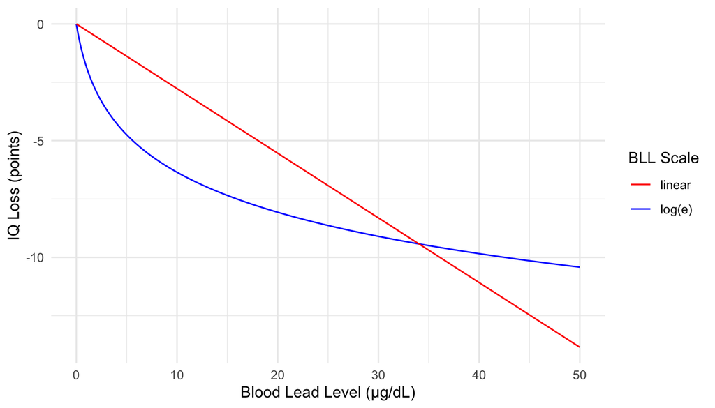

```r
library(ggplot2)
beta_log <- -2.650
beta_linear <- -0.277

blood_lead <- seq(0, 50, by = 0.1)

IQ_loss_log <- beta_log * log(blood_lead + 1)
IQ_loss_linear <- beta_linear * blood_lead

plot_data <- data.frame(
  blood_lead = blood_lead,
  log_ERF = IQ_loss_log,
  linear_ERF = IQ_loss_linear
)

ggplot(plot_data, aes(x = blood_lead)) +
  geom_line(aes(y = log_ERF, color = "log(e)")) +
  geom_line(aes(y = linear_ERF, color = "linear")) +
  scale_color_manual(values = c("log(e)" = "blue", "linear" = "red")) +
  labs(
    x = "Blood Lead Level (µg/dL)",
    y = "IQ Loss (points)",
    color = "BLL Scale"
  ) +
  theme_minimal()
```

It appears that we would heavily underestimate the effects of lower BLL and overestimate the effects of higher BLL. Since today, BLL are often found to be much lower than even 30 µg/dL (in our sample, the range is approximately 0.04 to 4.5 µg/dL), we would likely underestimate the population health effects of BLL on IQ in children.

Therefore, transforming log estimates to linear seems to be problematic in our case.

## 2.2 Transforming Estimates to log<sub>e</sub>(BLL)

In order to preserve the correct exposure-response curves and harmonize the effect estimates for the meta analysis, we could try to transform all estimates to log<sub>e</sub>(BLL), as this is closer to the original estimates reported by the studies, which mostly just used different bases for their logarithmic transformations.

These are the formulas I used to transform the different estimates to log<sub>e</sub>(BLL):
$$\beta_{ln} = \beta_{linear} \times C_{ref}\$$
$$\beta_{ln} = \frac{beta_{log_{2}}} {\ln(2)}\$$
$$\beta_{ln} = \frac{beta_{log_{10}}} {\ln(10)}\$$
Where:
$\beta_{ln}$ = harmonized beta coefficient (natural logarithm)
$\beta_{linear}$ = beta coefficient for linear BLL
$\beta_{log_2}$ = beta coefficient for log₂-transformed BLL
$\beta_{log_{10}}$ = beta coefficient for log₁₀-transformed BLL
$C_{ref}$ = reference concentration for linear transformation

### 2.2.1 Transforming log<sub>10</sub>(BLL) to log<sub>e</sub>(BLL): Dantzer et al. 2020 (2)

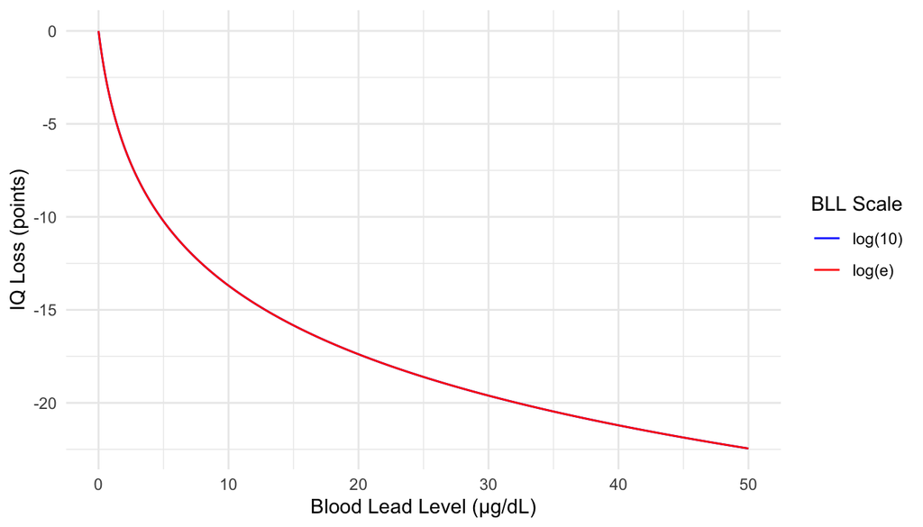

```r
Dantzerbeta_log10 <- -13.150
Dantzerbeta_ln <- -5.711

blood_lead <- seq(0, 50, by = 0.1)

IQ_loss_log10 <- Dantzerbeta_log10 * log10(blood_lead + 1)
IQ_loss_ln <- Dantzerbeta_ln * log(blood_lead + 1)

Dantzerplot_data <- data.frame(
  blood_lead = blood_lead,
  log_ERF = IQ_loss_log10,
  ln_ERF = IQ_loss_ln
)

ggplot(Dantzerplot_data, aes(x = blood_lead)) +
  geom_line(aes(y = log_ERF, color = "log(10)")) +
  geom_line(aes(y = ln_ERF, color = "log(e)")) +
  scale_color_manual(values = c("log(10)" = "blue", "log(e)" = "red")) +
  labs(
    x = "Blood Lead Level (µg/dL)",
    y = "IQ Loss (points)",
    color = "BLL Scale"
  ) +
  theme_minimal()
```

We can’t even see the blue curve, so the transformation should be valid.

### 2.2.2 Transforming log<sub>2</sub>(BLL) to log<sub>e</sub>(BLL): Desrochers-Couture et al. 2018 (3)

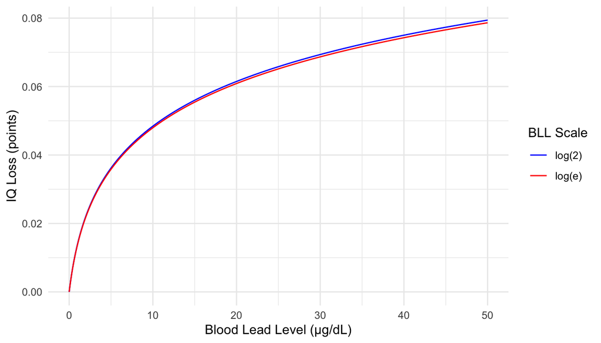

```r
Desrochersbeta_log2 <- 0.014
Desrochersbeta_ln <- 0.020

blood_lead <- seq(0, 50, by = 0.1)

IQ_loss_log2 <- Desrochersbeta_log2 * log2(blood_lead + 1)
IQ_loss_ln <- Desrochersbeta_ln * log(blood_lead + 1)

Desrochersplot_data <- data.frame(
  blood_lead = blood_lead,
  log_ERF = IQ_loss_log2,
  ln_ERF = IQ_loss_ln
)

ggplot(Desrochersplot_data, aes(x = blood_lead)) +
  geom_line(aes(y = log_ERF, color = "log(2)")) +
  geom_line(aes(y = ln_ERF, color = "log(e)")) +
  scale_color_manual(values = c("log(2)" = "blue", "log(e)" = "red")) +
  labs(
    x = "Blood Lead Level (µg/dL)",
    y = "IQ Loss (points)",
    color = "BLL Scale"
  ) +
  theme_minimal()
```

For the transformation from log<sub>2</sub> to ln, we can see that at least in this concentration range, the transformed estimate is a good approximation of the original.

**!** Note that this study reported a small protective effect of lead exposure, this is why the curve is flipped.

### 2.2.3 Transforming linear(BLL) to log<sub>e</sub>(BLL): Iglesias et al. 2011 (4)

In order to transform this estimate, we need to set a reference BLL ($C_{ref}$). Here, I chose 2.2 µg/dL.

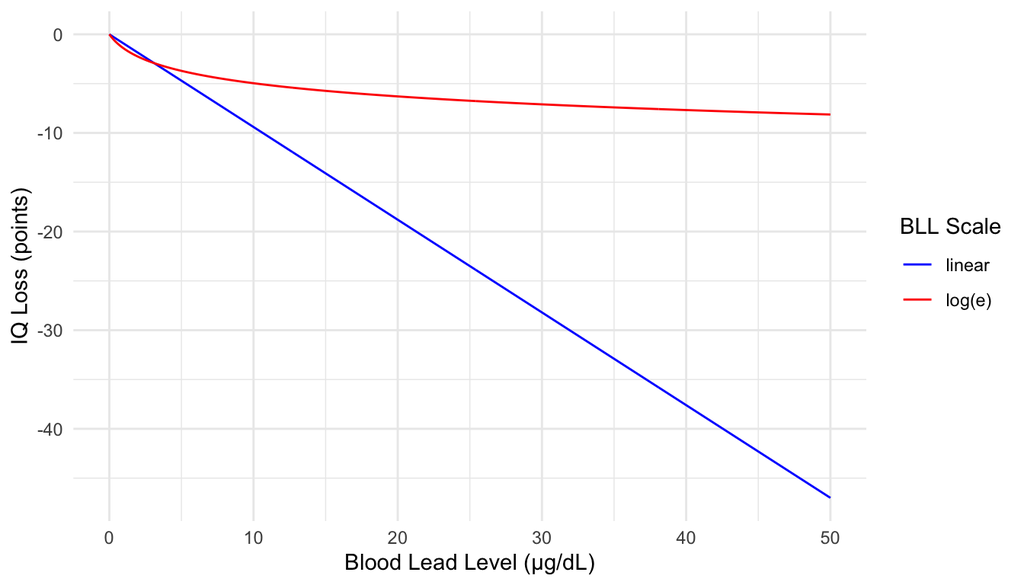

```r
Iglesiasbeta_linear <- -0.940
Iglesiasbeta_ln <- -2.068

blood_lead <- seq(0, 50, by = 0.1)

IQ_loss_linear <- Iglesiasbeta_linear * blood_lead
IQ_loss_ln <- Iglesiasbeta_ln * log(blood_lead + 1)

Iglesiasplot_data <- data.frame(
  blood_lead = blood_lead,
  linear_ERF = IQ_loss_linear,
  ln_ERF = IQ_loss_ln
)

ggplot(Iglesiasplot_data, aes(x = blood_lead)) +
  geom_line(aes(y = linear_ERF, color = "linear")) +
  geom_line(aes(y = ln_ERF, color = "log(e)")) +
  scale_color_manual(values = c("linear" = "blue", "log(e)" = "red")) +
  labs(
    x = "Blood Lead Level (µg/dL)",
    y = "IQ Loss (points)",
    color = "BLL Scale"
  ) +
  theme_minimal()
```

This looks problematic… However, the concentration range is quite high in this plot, so let’s zoom in.

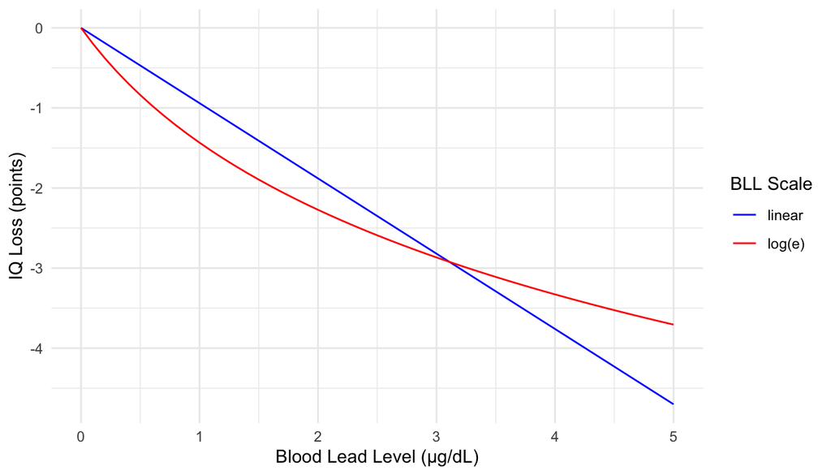

```r
blood_lead_low <- seq(0, 5, by = 0.1)

IQ_loss_linear <- Iglesiasbeta_linear * blood_lead_low
IQ_loss_ln <- Iglesiasbeta_ln * log(blood_lead_low + 1)

Iglesiasplot_data <- data.frame(
  blood_lead_low = blood_lead_low,
  linear_ERF = IQ_loss_linear,
  ln_ERF = IQ_loss_ln
)

ggplot(Iglesiasplot_data, aes(x = blood_lead_low)) +
  geom_line(aes(y = linear_ERF, color = "linear")) +
  geom_line(aes(y = ln_ERF, color = "log(e)")) +
  scale_color_manual(values = c("linear" = "blue", "log(e)" = "red")) +
  labs(
    x = "Blood Lead Level (µg/dL)",
    y = "IQ Loss (points)",
    color = "BLL Scale"
  ) +
  theme_minimal()
```

Even in the lower concentration range, it appears that the transformed estimate does not accurately approximate the original estimate. For my meta analysis, I therefore decided to exclude 3/15 studies with estimates for untransformed BLL data.  
This leaves us with 12 harmonized effect estimates for the association of log<sub>e</sub>(BLL) and absolute IQ point loss.  
These are the final studies and transformed effect estimates that we will be working with.

| author_year | doi | N | beta | se_beta |
| --- | --- | --- | --- | --- |
| Bauer 2020 | 10.1289/EHP6803 | 635 | -0.10 | 0.87 |
| Crump 2013 | 10.3109/10408444.2013.832726 | 1355 | -3.32 | 0.63 |
| Dantzer 2020 | 10.1016/j.scitotenv.2019.134519 | 224 | -5.71 | 1.61 |
| Desrochers-Couture 2018 | 10.1016/j.envint.2018.10.043 | 606 | 0.02 | 0.06 |
| Earl 2016 | 10.1111/ajpy.12096 | 127 | -5.86 | 2.21 |
| Hong 2015 | 10.1289/ehp.1307420 | 839 | -3.14 | 1.36 |
| Lee 2021 | 10.1016/j.envint.2021.106798 | 502 | -3.83 | 2.25 |
| Lucchini 2019 | 10.1186/s12940-019-0505-3 | 299 | -1.10 | 0.84 |
| Lucchini 2012 | 10.1016/j.envres.2012.08.003 | 299 | -3.48 | 1.48 |
| Menezes-Filho 2018 | 10.3390/ijerph15112418 | 155 | -3.74 | 1.29 |
| Roy 2013 | 10.1016/j.neuro.2013.05.005 | 708 | -4.70 | 1.66 |
| Schnaas 2006 | 10.1289/ehp.8552 | 150 | 0.17 | 0.81 |

# 3 Meta-Analysis

Now that we have collected our study data and harmonized the effect estimates, we can finally begin our meta analysis!

## 3.1 Setting Priors

First, we need to define the priors. In Bayesian statistics, a prior distribution represents our initial belief about an unknown parameter before observing any data. It’s a probability distribution reflecting our knowledge or assumptions about the parameter’s possible values. This prior distribution is then combined with the likelihood function (based on observed data) to produce a posterior distribution, which represents our updated belief after considering the data. You can read more about choosing prior distributions in Bayesian statistics in this [book chapter](https://bookdown.org/kevin_davisross/bayesian-reasoning-and-methods/prior.html#prior).  
We will be conservative and use weakly informative priors. For the main effect ($\mu$), I chose $\mu \sim \mathcal{N}(-1, 2)$. This means that we assume the main effect to lie between -3 and 1, with a 68.3% probability.

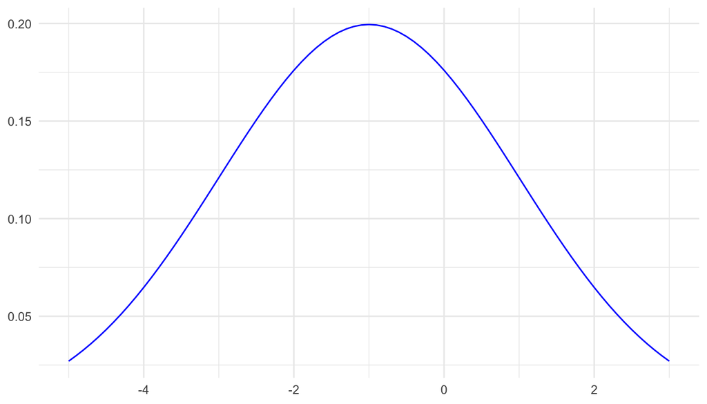

```r
mean <- -1
sd <- 2

lower <- -3
upper <- 1

# visualize distr
x <- seq((lower-2), (upper+2), by = 0.1)
y <- dnorm(x, mean, sd)
ggplot() +
  aes(x, y) +
  geom_line(colour = "blue") +
  theme_minimal() +
  labs(x= NULL, y = NULL)
```

Setting the prior for heterogeneity ($\tau$) is slightly more challenging since, by definition, it must be positive. Here, a truncated normal distribution can be useful.

For this model, I chose $\tau \sim \mathcal{N^+}(0, 2)$.

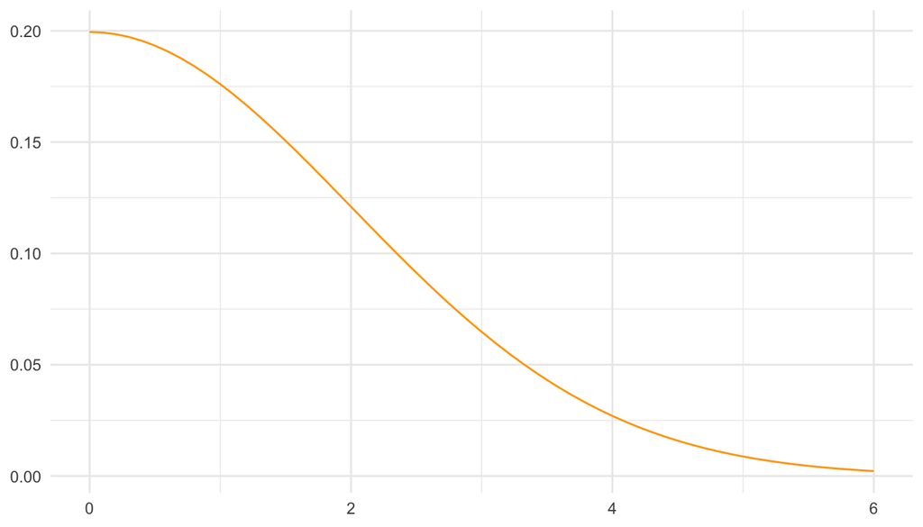

This is how we set our priors:

```r
priors <- c(prior(normal(-1, 2), class = Intercept),
            prior(normal(0, 2), class = sd, lb = 0))
```

## 3.2 Fitting the model

We can now write and fit the model, using the R package `brms` (5) version 2.22.0. In the second line we specify our model, which formalized looks like this (formula 3 and 4 refer to the priors):

$$\hat{\theta}_{k} \sim \mathcal{N}(\theta_{k}, \sigma_{k})\$$
$$\theta_{k} \sim \mathcal{N}(\mu_{k}, \tau_{k}) \$$
$$\mu \sim \mathcal{N}(-1, 2) \$$
$$\tau \sim \mathcal{TN}(0, 2, 0, inf)$$
Where:

$\hat{\theta}_{k}$ = Observed effect size of each study $k$  
$\theta_{k}$ = True effect size of included study $k$  
$\sigma_{k}^{2}$ = Variance of true effect size  
$\mu$ = Pooled effect size we want to estimate  
$\tau$ = Variance, representing between-study heterogeneity

In these formulas we can see the multilevel structure of our model very well: On the first level are individual participants and we assume that data from these individuals reach us through $\hat{\theta}_{k}$, the observed effect size. We then also assume (on level two) that the true effect size of the different studies $k$ also follow their own distribution which are characterized by the parameters we actually model ($\mu$ and $\tau^{2}$).

```r
n_chains <- 4
n_iter <- 4000

m.brm <- brm(
  beta_ln|se(se_beta_ln) ~ 1 + (1|author_year),
  data = data,
  prior = priors,
  save_pars = save_pars(all = TRUE),
  chains = n_chains,
  iter = n_iter)
```

Posterior draws are sampled using the Hamiltonian Monte Carlo algorithm (6) and the No-U-Turn Sampler (NUTS) (7). I decided to increase the number of draws we sample to 4000 (default: 2000). Since we run 4 chains and discard the first 2000 iterations of each chain as warmup, we end up with a total of 8000 posterior draws.

## 3.3 Diagnostics: Convergence & Model Validity

### 3.3.1 Prior & Posterior predictive checks

First, let’s make sure that our priors are reasonable. We can do this by doing a prior predictive check. Prior predictive checks are used to evaluate the suitability of prior distributions before the model ‘sees’ our data. This involves simulating data from the model using only the prior distributions and then examining the simulated data to see if it aligns with our expectations. This can help to identify issues with the chosen priors, such as implausible parameter values, before they can influence the posterior distribution and final inferences. You can read more about prior and posterior predictive checks [here](https://mc-stan.org/docs/stan-users-guide/posterior-predictive-checks.html).

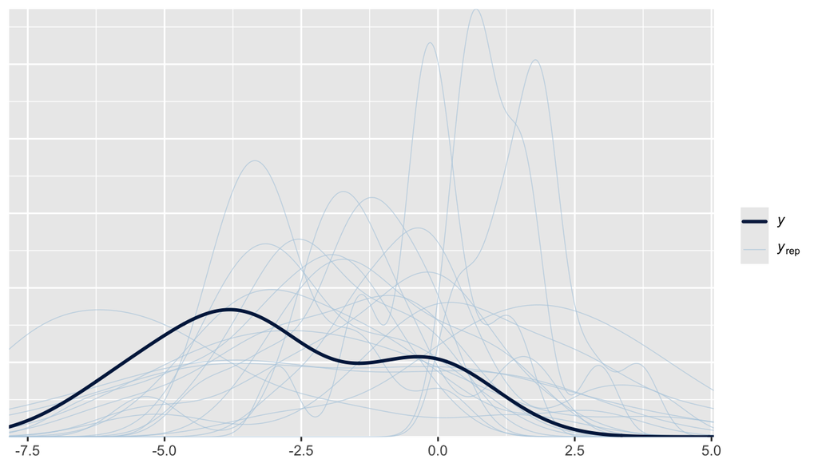

Now let’s do a posterior predictive check:

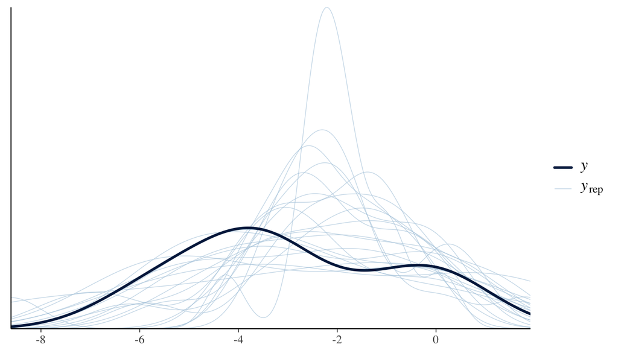

We mainly want to pay attention to extreme deviations from the area we’d expect our curves to land. Both look okay.

### 3.3.2 $\hat{R}$ value

Let’s look at the results summary:

```
 Family: gaussian
  Links: mu = identity; sigma = identity
Formula: beta_ln | se(se_beta_ln) ~ 1 + (1 | author_year)
   Data: data (Number of observations: 12)
  Draws: 4 chains, each with iter = 4000; warmup = 2000; thin = 1;
         total post-warmup draws = 8000

Multilevel Hyperparameters:
~author_year (Number of levels: 12)
              Estimate Est.Error l-95% CI u-95% CI Rhat Bulk_ESS Tail_ESS
sd(Intercept)     1.89      0.53     1.04     3.12 1.00     2413     3785

Regression Coefficients:
          Estimate Est.Error l-95% CI u-95% CI Rhat Bulk_ESS Tail_ESS
Intercept    -2.27      0.63    -3.54    -1.07 1.00     2403     3655

Further Distributional Parameters:
      Estimate Est.Error l-95% CI u-95% CI Rhat Bulk_ESS Tail_ESS
sigma     0.00      0.00     0.00     0.00   NA       NA       NA

Draws were sampled using sampling(NUTS). For each parameter, Bulk_ESS
and Tail_ESS are effective sample size measures, and Rhat is the potential
scale reduction factor on split chains (at convergence, Rhat = 1).
```

Here, we can see the posterior mean, SE and 95% quantiles for $\mathcal{beta}$, `Intercept` and $\mathcal{tau}$, `sd(Intercept)`. But before we focus on our results, we should take a few more steps to assess the quality of our results.  
In this output, we should pay attention to the $\hat{R}$ value (`Rhat` in output, potential scale reduction factor), which indicates whether the Markov chain Monte Carlo (MCMC) sampling process has converged. A value of less than 1.01 is generally considered good (8).  
[Here](https://mc-stan.org/rstan/reference/Rhat.html) you can read more about convergence and efficiency diagnostics for Markov chains. As we can see, our $\hat{R}$ values are both 1.00 which is good!

### 3.3.3 Effective Sample Size (ESS)

In the summary above, we also find `Bulk_ESS` and `Tail_ESS` for both the pooled effect `Intercept` and between-study heterogeneity `sd(Intercept)`. These values tell us something about how much we can trust our results (for the *bulk* and the *tails* of our posterior distribution).  
When the MCMC algorithm moves around the parameter space we want to learn about, each new step (or iteration) is dependent on the last one. This means that the samples we generate are somewhat correlated. The ESS value gives us an idea of how many *truly independent* samples would give us the same quality of information as the correlated samples. In our case, ESS for the bulk of the posterior distribution for `Intercept` is 2403. This means that, in simple terms, our estimate is as good as 2403 independent samples. This corresponds to 30% of our total samples, which is good.

### 3.3.4 Monte Carlo Standard Error (MCSE)

MCSE measures the uncertainty in our estimate that results from not sampling an infinite amount of draws. If we run our model several times, we will get a slightly different posterior mean every time. This is due to the inherent probabilistic nature of the Bayesian approach.

MCSE quantifies how much the posterior mean typically varies and helps us to decide if we need more iterations to get reliable estimates. In our case, mean MCSE of `Intercept` is 0.013. Now we compare this value to the standard deviation of `Intercept`, which is 0.632.

$$\frac {0.013} {0.632} = 0.02$$

That’s good precision! The MCMC error (or the simulation noise) contributes only 2% of the total uncertainty.  
**To Do: revise this section!** Good resource: [article from Aki Vehtari](https://users.aalto.fi/~ave/casestudies/Digits/digits.html)

### 3.3.5 Trace Plots

Now let’s look at the trace plots of the four MCMC chains for both the posterior distribution of $\mathcal{beta}$ and the between-study heterogeneity $\mathcal{tau}$. These are all the 4000 samples the MCMC algorithm took from the parameter space it explored. The colors indicate the four different chains. The red vertical lines show where the warm-up ended (samples from the warm-up will not be used further).

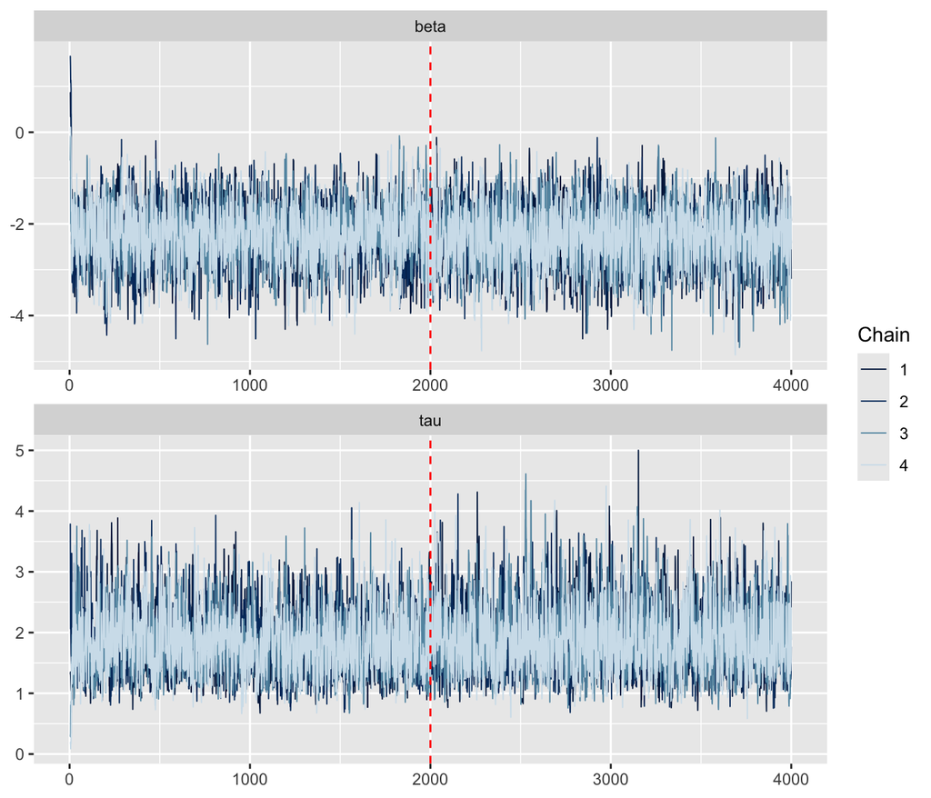

## 3.4 Interpreting the Results

The posterior probability distribution represents the updated beliefs about an unknown parameter (e.g. the effect of BLL on IQ, $\mathcal{beta}$) after observing new data, combining prior beliefs with the evidence from the data.  
Let’s visualize this!

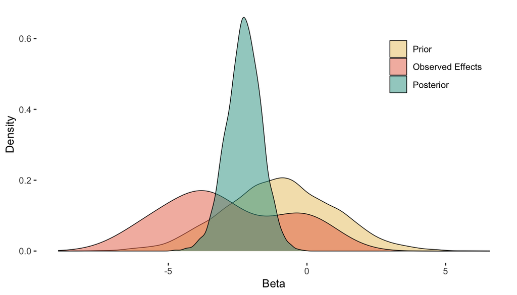

In this plot, we can nicely see how the data we observed convinced us that the effect is a bit stronger than we assumed (we formalized this with the prior distribution). Also, the model didn’t really trust the results of studies that showed a large effect. If you’re wondering why the prior doesn’t look completely smooth, this is because what we see in this plot are the actual samples the MCMC algorithm took from the prior distribution we set.

Unlike a mean effect + confidence interval, a posterior distribution actually represents probability!  
This means that we can ‘ask’ this distribution many questions, such as: “What is the probability that the pooled effect ($\mathcal{beta}$) is greater than -1?” ( *greater* meaning *stronger* here, so more IQ points would be lost). To answer such questions, we use the empirical cumulative distribution function (ECDF):

```r
b.ecdf <- ecdf(posterior_samples$beta)
x <- b.ecdf(-1)
```

Given our data and model, the probability of the effect being greater than -1 is 98%.  
We can also ask about intervals; for example a high-density interval (HDI). This is the narrowest interval containing X% of the probability mass of the posterior distribution. This interval is often referred to as *credible interval*. Let’s compute a 90% HDI!

```r
hdi <- hdi(posterior_samples$beta, credMass = 0.90)
```

Given our data and model, the true effect lies between -3.25 and -1.19 with 90% probability.

And of course, we can also plot a pretty forest plot showing all the posterior distributions of the included studies, the mean, and the 95% credible intervals.

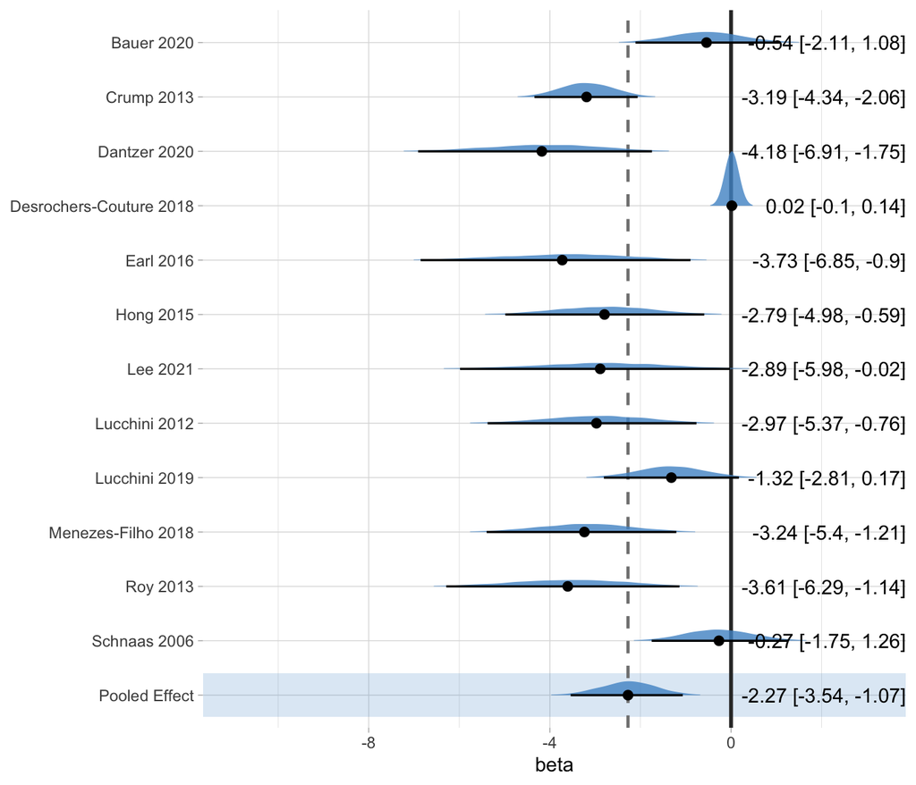

If you’re wondering why the effect sizes are not the same as those reported in the studies, it’s because of a process called *shrinkage*. The Bayesian model estimates ‘true’ effect sizes for each study and if it detects outliers, they will be pulled towards the overall effect. This is an advantage of the Bayesian approach, particularly when pooling a small number of studies. The model is less sensitive to outliers than frequentist models.

Coming back to the main objective of this project, we can now use the posterior distribution directly for our EBD assessment!

## References

1.

Crump KS, Van Landingham C, Bowers TS, Cahoy D, Chandalia JK. [A statistical reevaluation of the data used in the Lanphear et al. ( 2005 ) pooled-analysis that related low levels of blood lead to intellectual deficits in children](https://doi.org/10.3109/10408444.2013.832726). Crit Rev Toxicol. 2013;43(9):785–99.

2.

Dantzer J, Ryan P, Yolton K, Parsons PJ, Palmer CD, Cecil K, et al. [A comparison of blood and toenails as biomarkers of children’s exposure to lead and their correlation with cognitive function](https://doi.org/10.1016/j.scitotenv.2019.134519). Science of The Total Environment. 2020;700:134519.

3.

Desrochers-Couture M, Oulhote Y, Arbuckle TE, Fraser WD, Séguin JR, Ouellet E, et al. [Prenatal, concurrent, and sex-specific associations between blood lead concentrations and IQ in preschool Canadian children](https://doi.org/10.1016/j.envint.2018.10.043). Environment International. 2018;121:1235–42.

4.

Iglesias V, Steenland K, Maisonet M, Pino P. [Exposure to Lead from a Storage Site Associated with Intellectual Impairment in Chilean Children Living Nearby](https://doi.org/10.1179/107735211799041841). International Journal of Occupational and Environmental Health. 2011;17(4):314–21.

5.

Bürkner PC. [**Brms** : An *R* Package for Bayesian Multilevel Models Using *Stan*](https://doi.org/10.18637/jss.v080.i01). J Stat Soft. 2017;80(1).

6.

Betancourt M. [A Conceptual Introduction to Hamiltonian Monte Carlo](https://doi.org/10.48550/ARXIV.1701.02434). arXiv; 2017.

7.

Hoffman MD, Gelman A. [The No-U-Turn Sampler: Adaptively Setting Path Lengths in Hamiltonian Monte Carlo](https://doi.org/10.48550/ARXIV.1111.4246). arXiv; 2011.

8.

Gelman A, Rubin DB. [Inference from Iterative Simulation Using Multiple Sequences](https://doi.org/10.1214/ss/1177011136). Statist Sci. 1992 Nov;7(4).